# AB REP Surplus from Hastings-Simon et al (2022)

2022-08-12

## REP CFD Valuation

The contracts-for-differences procured through the REP have been net positive for the government to date, driven by an increase in wholesale power prices in Alberta in 2021 and 2022 year-to-date. We estimate the value of the REP contract portfolio to date starting with the hourly surplus value generated on power sales relative to project-specific, inflation-adjusted contract strike prices, to which we add an estimate of the value of greenhouse gas emissions credits (EC) transferred to the government under the REP contracts at market carbon prices (τ_t). These are each multiplied by hourly production for each project from the first hour in which a facility was in commercial operation, through to the end-of-day July 31, 2022.

We make three important assumptions to value the portfolio of contracts.

First, we use the capacity-weighted average strike prices for each REP round as a proxy for project-specific strike prices, as project-specific information was not disclosed.

Second, ww assume that the lowest strike price in REP round 1 (CA$30.90/MWh) was associated with the Sharp Hills project that terminated its support agreement and, based on this assumption, we adjust the capacity-weighted average strike price for first round contracts to CA$41.36/MWh, which we apply to the remaining three round 1 projects.

Finally, we estimate the value of surrendered environmental attributes based on the annual value of emissions performance credits that would have otherwise been allocated to the projects at a rate of 0.37t/MWh under Alberta’s carbon pricing policy, the Technology and Innovation Emissions Reduction Regulation (2019), multiplied by annual carbon prices established in the regulation.

This document details how we set the preliminaries for our analysis.

```r
#CPI Adjustments for REP1 projects. REP3 still at 1, since the only project in-service came on-line this year.
cpi<-function(year,REP="REP1"){
      ret<-case_when(
        (as.character(year)==2019) ~ 0.97801,
        (as.character(year)==2020) ~ 1.00000,
        (as.character(year)==2021) ~  1.00733,
        (as.character(year)==2022) &  (REP=="REP1") ~  1.05572,
        (as.character(year)=="2022 (YTD)") &  (REP=="REP1")~ 1.05572,
        TRUE ~ 1)
      ret
}

#define the REP projects
    REP_projects<-c("RIV1","CRR2","WHT1","WRW1")
```

This document uses publicly-avaialble AESO data. The paper uses the same data for this analysis, but for longer-term history we use AESO data as scraped and provided by NRGStream.

```r
#use updated AESO MV data to calculate REP contract values

aeso_file<-read.csv("https://www.aeso.ca/assets/Uploads/data-requests/Hourly_Metered_Volumes_and_Pool_Price_and_AIL.csv")
#make a local version if you want to run it faster or make changes
#save(aeso_file,file="aeso_file_local.RData")
#load("aeso_file_local.RData")

  aeso_rep<-aeso_file %>%
      select(-Date_Begin_GMT)%>%
      rename("Market"=ACTUAL_AIL)%>%
      pivot_longer(-c(Date_Begin_Local,"ACTUAL_POOL_PRICE","DAY_AHEAD_POOL_PRICE",
                   "EXPORT_BC","EXPORT_MT","EXPORT_SK","IMPORT_BC",
                   "IMPORT_MT","IMPORT_SK"),
                   names_to = "ID", values_to = "gen")%>%
      filter(ID %in% c(REP_projects,"Market"))%>%
      mutate(time=mdy_hm(Date_Begin_Local))%>%
      select(-Date_Begin_Local)%>%
      filter(!is.na(gen))%>%
      select(time,price=ACTUAL_POOL_PRICE,ID,gen)%>%
      mutate(year=year(time),
             power_value=gen*price)%>%
      filter(as.numeric(as.character(year))>=2019)%>%
      #value carbon credits
      mutate(env_attr=case_when(
        (ID %in% REP_projects)& year==2019 ~30*.37,
        (ID %in% REP_projects)& year==2020 ~30*.37,
        (ID %in% REP_projects)& year==2021 ~40*.37,
        (ID %in% REP_projects)& year==2022 ~50*.37,
        TRUE~0
      ))%>%
      #assign rep series
      mutate(rep=case_when(
        (ID=="WHT1") ~ "REP1",
        (ID=="WRW1") ~ "REP3",
        (ID=="RIV1") ~ "REP1",
        (ID=="CRR2") ~ "REP1",
        TRUE ~ "Not in REP"))%>%
      #assign REP strike prices
      mutate(raw_strike=case_when(
        (rep=="REP1") ~ 41.36,
        (rep=="REP2") ~ 38.69,
        (rep=="REP3") ~ 40.14,
        TRUE ~ 0))%>%
      #adjust strikes for inflation, then calculate net positions
      group_by(year)%>%
      #calculate generation by year for the graph labels
      mutate(
       rep_gen_year=sum(gen*(ID %in% REP_projects))
       )%>%
      ungroup()%>%
      mutate(
        strike=raw_strike*(.8+.2*cpi(year,rep)),
        #value the cfd
        cfd_val=strike*gen,
        #hourly value on power
        net_govt_power=(price-strike)*gen,
        #hourly environmental attr value
        env_ttl=env_attr*gen,
        #hourly net
        net_govt_ttl=net_govt_power+env_ttl,
        #set up the years so we can label the YTD
        year=as.factor(year),
        year_mod=fct_recode(year,"2022 (YTD)"="2022"),
        label=paste(as.character(year_mod),"\n\n","(",round(rep_gen_year/10^3,0)," GWh of REP-\nsupported generation)",sep="")
     )%>%
      #create yearly summaries by ID. Preserve the labels
      group_by(year,ID,label)%>%
      summarize(cfd_surplus=sum(net_govt_power),
                env_surplus=sum(env_ttl),
                #net_govt_ttl=net_govt_power+env_ttl,
                env_ttl=sum(env_ttl,na.rm = T)/sum(gen,na.rm = T),
                power_val=sum(price*gen)/sum(gen),
                total_val=power_val+env_ttl
                )%>%
      ungroup()%>%
      #get the order by COD, with market on the left
      mutate(
        ID=fct_relevel(ID,"WHT1","CRR2","RIV1","WRW1"),
        ID=fct_relevel(ID,"Market"),
        ID=fct_recode(ID,"Market Generation-Weighted Average Price"="Market"),
        ID=fct_recode(ID,"Whitla 1 (REP1)"="WHT1","Castle Rock Ridge 2 (REP1)"="CRR2","Riverview Wind (REP1)"="RIV1","Windrise Wind (REP3)"="WRW1"),
        #Plant_Type=fct_reorder(Plant_Type,startup,min),
      )
```

And, so using these data, we can summarize the annual surplus (net of and including the value of environmental attributes surrendered by the project proponents):

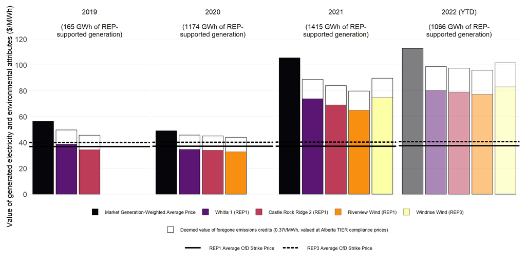

```r
    #create the figure
    aeso_rep_plant_cpi_graph<-ggplot(aeso_rep)+
      geom_col(aes(ID,power_val,fill=ID),size=.25,position=position_dodge(width=0.9),color="black",alpha=0.5)+
      geom_col(aes(ID,y=total_val,color="Deemed value of foregone emissions credits (0.37t/MWh, valued at Alberta TIER compliance prices)"),fill=NA,alpha=0.5,size=.5,position=position_dodge(width=0.9))+
      facet_wrap(~label,nrow=1)+
      #scale_fill_grey("")+
      scale_fill_viridis("",option = "B",discrete = T,direction = 1)+
      scale_color_manual("",values=c("black"))+
      scale_linetype_manual("",values=c("solid","21","22"))+
      scale_y_continuous(breaks = pretty_breaks(),expand=c(0,0))+
      expand_limits(y=0)+
      paper_theme()+
      theme(legend.position = "bottom",legend.box="vertical", legend.margin=margin(),
            legend.text=element_text(size=rel(2)),
            axis.text.x = element_blank(),
            NULL)+
      expand_limits(y=120)+
      guides(#fill="none",
        fill=guide_legend(order = 1,nrow = 1,label.position = "right",keywidth = 1,keyheight = 1),
        linetype=guide_legend(order = 3,nrow = 1,keywidth = 3),
        color=guide_legend(order = 2,ncol = 1,label.position = "right",keywidth = 1,keyheight = 1))+
      labs(x="",y="Value of generated electricity and environmental attributes ($/MWh)",
           #title="Energy Price Capture ($/MWh, 2010-2021)",
           #caption="Source: AESO Data, accessed via NRGStream\nGraph by @andrew_leach"
      )

    aeso_rep_plant_cpi_graph+
      geom_col(data=aeso_rep%>% filter(year!="2022"),aes(ID,power_val,fill=ID),size=.25,position=position_dodge(width=0.9),
               color="black",alpha=.95)+
      geom_col(data=aeso_rep%>% filter(year!="2022"),aes(ID,total_val,
               color="Deemed value of foregone emissions credits (0.37t/MWh, valued at Alberta TIER compliance prices)"),
               fill=NA,alpha=0.25,size=.5,position=position_dodge(width=0.9))+
      geom_hline(aes(yintercept=37*(.8+.2*cpi(year)),lty="REP1 Average CfD Strike Price"),color="black",size=1.5)+
      #omit REP 2 since no projects included
      #geom_hline(aes(yintercept=38.69*(.8+.2*cpi(year)),lty="REP2 Average CfD Strike Price"),color="black",size=1.5)+
      geom_hline(aes(yintercept=40.14*(.8+.2*cpi(year)),lty="REP3 Average CfD Strike Price"),color="black",size=1.5)+
      NULL
```

And, these data also yield the cumulative totals cited in the paper:

- Total CfD portfolio surplus: 75.536 million
- Total value of GHG emissions credits: 55.523 million
- Total combined surplus: 131.058 million